# Prediction of Exercise Manners

Lin Htet Naing

9/7/2021

## Background

Using devices such as Jawbone Up, Nike FuelBand, and Fitbit it is now possible to collect a large amount of data about personal activity relatively inexpensively. These type of devices are part of the quantified self movement – a group of enthusiasts who take measurements about themselves regularly to improve their health, to find patterns in their behavior, or because they are tech geeks. One thing that people regularly do is quantify how much of a particular activity they do, but they rarely quantify how well they do it. The goal of the project is to predict the manner in which study participants did the exercise.

## Data

The training data for this project are from here:

https://d396qusza40orc.cloudfront.net/predmachlearn/pml-training.csv

The test data are from here:

https://d396qusza40orc.cloudfront.net/predmachlearn/pml-testing.csv

## Data cleaning

```r
library(randomForest)
library(caret)
```

```r
library(lattice)
library(ggplot2)
library(rpart)
library(rpart.plot)

#Load datasets
trainingset <- read.csv("pml-training.csv", na.strings=c("NA","#DIV/0!", ""))
testingset <- read.csv("pml-testing.csv", na.strings=c("NA","#DIV/0!", ""))
```

Looking into data sets and relevant exploratory data analysis are done. The data sets contain variables which cannot be used for prediction and variables with ‘NA’ values. Data cleaning is performed to get tidy data sets which are ready to use for the required analysis. For reproducibilty, set.seed(1) is set.

```r
set.seed(1)
#Delete columns with all missing values
trainingset<-trainingset[,colSums(is.na(trainingset)) == 0]
testingset <-testingset[,colSums(is.na(testingset)) == 0]

#Delete variables which cannot be use or are irrelevant to the project such as: user_name, raw_timestamp_part_1, raw_timestamp_part_, etc.
trainingset   <-trainingset[,-c(1:7)]
testingset <-testingset[,-c(1:7)]

#Data partition - 75% of the training dataset into training (myTrain) and the remaining 25% to testing (myTest)
inTrain <- createDataPartition(y=trainingset$classe, p=0.75, list=FALSE)
myTrain <- trainingset[inTrain, ]
myTest <- trainingset[-inTrain, ]

#Check complete cases
completeCase <- complete.cases(myTrain)
nrows <- nrow(myTrain)
sum(completeCase) == nrows
```

```
## [1] TRUE
```

The result ‘TRUE’ confirms that observations included in myTrain dataset are complete.

```r
completeCase <- complete.cases(myTest)
nrows <- nrow(myTest)
sum(completeCase) == nrows
```

```
## [1] TRUE
```

Also, observations in myTest are complete.

```r
#Convert the variable 'classe' to factor
myTrain$classe <- as.factor(myTrain$classe)
myTest$classe <- as.factor(myTest$classe)

table(myTrain$classe)
```

```
##
##    A    B    C    D    E
## 4185 2848 2567 2412 2706
```

According to the table, the frequencies of four classes (B, C, D and E) are not much different from each other but class A has the highest frequency.

## Procedure

The manner (outcome) represented by the variable ‘classe’ will be predicted by using the most accurate model. The variable ‘classe’ contains five levels of factor from A to E. Each class represents a specific manner in which participants did exercise. Two models - random forest and decision tree will be tested, and the model with the highest accuracy will be selected as final model and used for prediction of manner in testing data set.

Original training data set contains a large number of observations which are sufficient to divide the data set into two. The training data set are divided randomly into two subsamples: myTrain data set (75% of original data) and myTest data set (25% of original data). For cross validation, models fitted by using myTrain data set will be tested on the myTest data set.

## Fitting Models

### Random Forest

```r
#Models
#Random Forest
model1 <- randomForest(classe ~., data = myTrain)
model1
```

```
##
## Call:
##  randomForest(formula = classe ~ ., data = myTrain)
##                Type of random forest: classification
##                      Number of trees: 500
## No. of variables tried at each split: 7
##
##         OOB estimate of  error rate: 0.41%
## Confusion matrix:
##      A    B    C    D    E  class.error
## A 4184    0    0    0    1 0.0002389486
## B   10 2836    2    0    0 0.0042134831
## C    0   19 2547    1    0 0.0077911959
## D    0    0   21 2390    1 0.0091210614
## E    0    0    0    6 2700 0.0022172949
```

#### Prediction on myTest using model 1 (Random Forest)

```r
#Prediction model1
predictModel1 <- predict(model1, newdata = myTest, class = "class")
Model1CM <- confusionMatrix(predictModel1, myTest$classe)
Model1CM
```

```
## Confusion Matrix and Statistics
##
##           Reference
## Prediction    A    B    C    D    E
##          A 1393    3    0    0    0
##          B    2  946   12    0    0
##          C    0    0  843   12    0
##          D    0    0    0  792    5
##          E    0    0    0    0  896
##
## Overall Statistics
##
##                Accuracy : 0.9931
##                  95% CI : (0.9903, 0.9952)
##     No Information Rate : 0.2845
##     P-Value [Acc > NIR] : < 2.2e-16
##
##                   Kappa : 0.9912
##
##  Mcnemar's Test P-Value : NA
##
## Statistics by Class:
##
##                      Class: A Class: B Class: C Class: D Class: E
## Sensitivity            0.9986   0.9968   0.9860   0.9851   0.9945
## Specificity            0.9991   0.9965   0.9970   0.9988   1.0000
## Pos Pred Value         0.9979   0.9854   0.9860   0.9937   1.0000
## Neg Pred Value         0.9994   0.9992   0.9970   0.9971   0.9988
## Prevalence             0.2845   0.1935   0.1743   0.1639   0.1837
## Detection Rate         0.2841   0.1929   0.1719   0.1615   0.1827
## Detection Prevalence   0.2847   0.1958   0.1743   0.1625   0.1827
## Balanced Accuracy      0.9989   0.9966   0.9915   0.9919   0.9972
```

The accuracy for prediction using random forest is 0.9931 and the expected out of sample error rate is 0.0069.

### Decision Tree

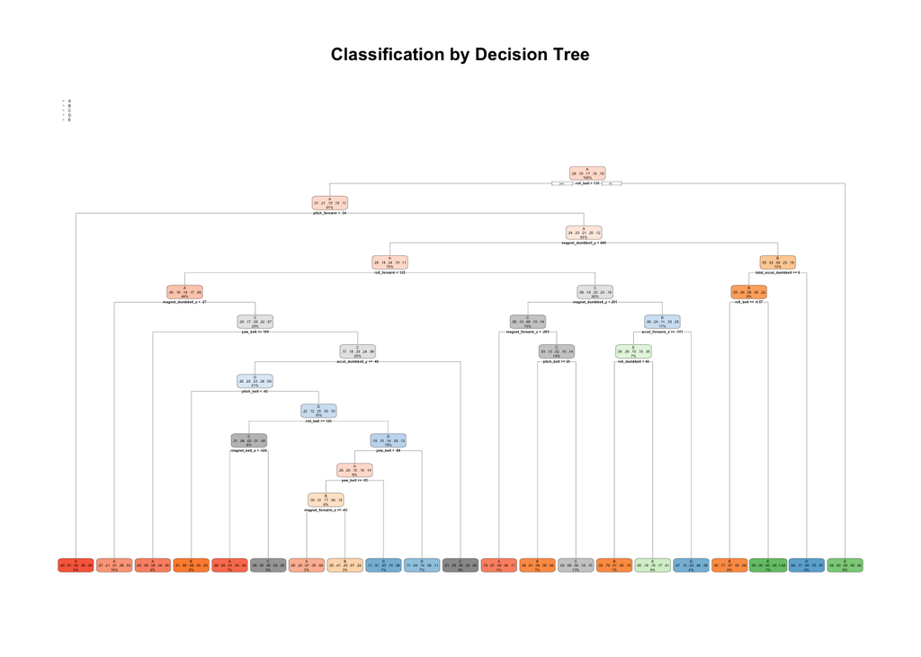

```r
#Decision Tree
model2 <- rpart(classe ~., data = myTrain, method = "class")
rpart.plot(model2,  main = "Classification by Decision Tree")
```

#### Prediction on myTest using model 2 (Decision Tree)

```r
#Prediction Model2
predictModel2 <- predict(model2, newdata = myTest, type = "class")
Model2CM <- confusionMatrix(predictModel2, myTest$classe)
Model2CM
```

```
## Confusion Matrix and Statistics
##
##           Reference
## Prediction    A    B    C    D    E
##          A 1214  200   23   79   36
##          B   41  547   74   31   79
##          C   41   84  658  102   92
##          D   67   58   52  553   99
##          E   32   60   48   39  595
##
## Overall Statistics
##
##                Accuracy : 0.7274
##                  95% CI : (0.7147, 0.7398)
##     No Information Rate : 0.2845
##     P-Value [Acc > NIR] : < 2.2e-16
##
##                   Kappa : 0.654
##
##  Mcnemar's Test P-Value : < 2.2e-16
##
## Statistics by Class:
##
##                      Class: A Class: B Class: C Class: D Class: E
## Sensitivity            0.8703   0.5764   0.7696   0.6878   0.6604
## Specificity            0.9037   0.9431   0.9212   0.9327   0.9553
## Pos Pred Value         0.7822   0.7085   0.6735   0.6671   0.7687
## Neg Pred Value         0.9460   0.9027   0.9498   0.9384   0.9259
## Prevalence             0.2845   0.1935   0.1743   0.1639   0.1837
## Detection Rate         0.2476   0.1115   0.1342   0.1128   0.1213
## Detection Prevalence   0.3165   0.1574   0.1992   0.1690   0.1578
## Balanced Accuracy      0.8870   0.7598   0.8454   0.8102   0.8078
```

The accuracy for prediction by decision tree is 0.7274 and the expected out of sample error is 0.2726.

## Prediction on Testing data set

```r
#Model1 Random Forest
RFtesting <- predict(model1, newdata = testingset)
RFtesting
```

```
##  1  2  3  4  5  6  7  8  9 10 11 12 13 14 15 16 17 18 19 20
##  B  A  B  A  A  E  D  B  A  A  B  C  B  A  E  E  A  B  B  B
## Levels: A B C D E
```

```r
#Model2 Decision Tree
DTtesting <- predict(model2, newdata = testingset, type = "class")
DTtesting
```

```
##  1  2  3  4  5  6  7  8  9 10 11 12 13 14 15 16 17 18 19 20
##  B  A  E  D  A  C  D  A  A  A  C  E  C  A  E  D  A  A  A  B
## Levels: A B C D E
```

## Final Model

```r
Final <- predict(model1, testingset, type = "class")
Final
```

```
##  1  2  3  4  5  6  7  8  9 10 11 12 13 14 15 16 17 18 19 20
##  B  A  B  A  A  E  D  B  A  A  B  C  B  A  E  E  A  B  B  B
## Levels: A B C D E
```